# Calidad del aire - EDA

Luis J Rubio

2026-02-06

### Pasos que se seguiran en este codigo

1. Carga de librerias.
2. Carga de datos.
3. Analisis descriptivo.
4. Ajuste de tipos de variables.
5. Deteccion y tratamiento de datos ausentes.
6. Deteccion y tratamiento de valores atipicos.
7. Analisis de correlacion entre variables.

## Paso 1: Cargar las librerias

```r
#Carga de librerias
library(readr)
library(ggplot2)
library(Hmisc)
library(corrplot)
library(dplyr)
```

## Paso 2: Cargar datos

```r
calidad_aire<-
  read_delim("data/calidad-del-aire-datos-historicos-diarios.csv",
             delim=";", col_names = TRUE, locale = locale(encoding = "UTF-8"))
```

Veamos algunas filas del dataset

```r
head(calidad_aire)
```

```
## # A tibble: 6 × 13
##   Fecha      `CO (mg/m3)` `NO (ug/m3)` `NO2 (ug/m3)` `O3 (ug/m3)` `PM10 (ug/m3)`
##   <date>            <dbl>        <dbl>         <dbl>        <dbl>          <dbl>
## 1 2020-12-31         NA              1             1           53              1
## 2 2020-12-31         NA              5             3           57              4
## 3 2020-12-31         NA              2            21           41             NA
## 4 2020-12-31         NA              1             9           44             NA
## 5 2020-12-31         NA              1             1           81             NA
## 6 2020-12-31          0.9            6            24           NA              7
## # ℹ 7 more variables: `PM25 (ug/m3)` <dbl>, `SO2 (ug/m3)` <dbl>,
## #   Provincia <chr>, Estación <chr>, Latitud <dbl>, Longitud <dbl>,
## #   Posición <chr>
```

## Paso 3: Analisis exploratorio

La función **str()** permite conocer de forma compacta la estructura interna de la tabla de datos indicando el tipo de variables, los rangos de valores y una muestra de dichos valores donde de un vistazo se puede apreciar la presencia de valores ausentes identificados mediante las siglas **NA** (del inglés, not allowed o no disponible)

```r
str(calidad_aire)
```

```
## spc_tbl_ [446,014 × 13] (S3: spec_tbl_df/tbl_df/tbl/data.frame)
##  $ Fecha       : Date[1:446014], format: "2020-12-31" "2020-12-31" ...
##  $ CO (mg/m3)  : num [1:446014] NA NA NA NA NA 0.9 NA NA NA NA ...
##  $ NO (ug/m3)  : num [1:446014] 1 5 2 1 1 6 4 3 6 7 ...
##  $ NO2 (ug/m3) : num [1:446014] 1 3 21 9 1 24 19 14 16 22 ...
##  $ O3 (ug/m3)  : num [1:446014] 53 57 41 44 81 NA 44 52 64 45 ...
##  $ PM10 (ug/m3): num [1:446014] 1 4 NA NA NA 7 10 9 4 3 ...
##  $ PM25 (ug/m3): num [1:446014] 1 NA NA NA NA 6 6 NA NA NA ...
##  $ SO2 (ug/m3) : num [1:446014] 3 3 NA NA 2 NA NA 2 2 9 ...
##  $ Provincia   : chr [1:446014] "Palencia" "Palencia" "Valladolid" "Valladolid" ...
##  $ Estación    : chr [1:446014] "C.T.G. - Compuerto" "Hontoria 2 - Venta de Baños" "Michelin1" "VALLADOLID SUR" ...
##  $ Latitud     : num [1:446014] 42.8 41.9 41.7 41.6 40.6 ...
##  $ Longitud    : num [1:446014] -4.84 -4.47 -4.71 -4.77 -6.22 ...
##  $ Posición    : chr [1:446014] "42.8491666667,-4.83583333333" "41.9480555556,-4.46583333333" "41.6663888889,-4.715" "41.6113888889,-4.77222222222" ...
##  - attr(*, "spec")=
##   .. cols(
##   ..   Fecha = col_date(format = ""),
##   ..   `CO (mg/m3)` = col_double(),
##   ..   `NO (ug/m3)` = col_double(),
##   ..   `NO2 (ug/m3)` = col_double(),
##   ..   `O3 (ug/m3)` = col_double(),
##   ..   `PM10 (ug/m3)` = col_double(),
##   ..   `PM25 (ug/m3)` = col_double(),
##   ..   `SO2 (ug/m3)` = col_double(),
##   ..   Provincia = col_character(),
##   ..   Estación = col_character(),
##   ..   Latitud = col_double(),
##   ..   Longitud = col_double(),
##   ..   Posición = col_character()
##   .. )
##  - attr(*, "problems")=<externalptr>
```

La función **summary()** muestra un resumen general de las variables de la tabla, mostrando los valores: mínimo, máximo, media, mediana, primer y tercer cuartil para las variables numéricas, indicando además el número específico de valores NA presentes en cada una.

```r
summary(calidad_aire)
```

```
##      Fecha              CO (mg/m3)       NO (ug/m3)       NO2 (ug/m3)
##  Min.   :1997-01-01   Min.   : 0.00    Min.   :-441.00   Min.   :  0.00
##  1st Qu.:2004-07-26   1st Qu.: 0.30    1st Qu.:   2.00   1st Qu.:  8.00
##  Median :2009-09-11   Median : 0.70    Median :   5.00   Median : 16.00
##  Mean   :2009-09-11   Mean   : 0.85    Mean   :  13.23   Mean   : 21.41
##  3rd Qu.:2015-02-10   3rd Qu.: 1.10    3rd Qu.:  15.00   3rd Qu.: 29.00
##  Max.   :2020-12-31   Max.   :25.10    Max.   : 634.00   Max.   :249.00
##                       NA's   :344856   NA's   :30984     NA's   :32517
##    O3 (ug/m3)      PM10 (ug/m3)     PM25 (ug/m3)     SO2 (ug/m3)
##  Min.   :  0.00   Min.   :  0.0    Min.   :  0.00   Min.   :-791.000
##  1st Qu.: 37.00   1st Qu.: 11.0    1st Qu.:  5.00   1st Qu.:   2.000
##  Median : 54.00   Median : 18.0    Median :  9.00   Median :   5.000
##  Mean   : 52.62   Mean   : 22.7    Mean   : 13.68   Mean   :   9.093
##  3rd Qu.: 68.00   3rd Qu.: 29.0    3rd Qu.: 15.00   3rd Qu.:  11.000
##  Max.   :999.00   Max.   :557.0    Max.   :223.00   Max.   : 364.000
##  NA's   :170600   NA's   :101435   NA's   :392230   NA's   :89737
##   Provincia           Estación            Latitud         Longitud
##  Length:446014      Length:446014      Min.   :38.94   Min.   :-6.782
##  Class :character   Class :character   1st Qu.:41.65   1st Qu.:-6.484
##  Mode  :character   Mode  :character   Median :42.54   Median :-4.909
##                                        Mean   :42.15   Mean   :-5.179
##                                        3rd Qu.:42.69   3rd Qu.:-4.538
##                                        Max.   :43.60   Max.   :-2.467
##                                        NA's   :226     NA's   :226
##    Posición
##  Length:446014
##  Class :character
##  Mode  :character
##
##
##
##
```

Según los resully¿tados obtenidos, las principales caracteríaticas que presenta la tabla de datos son:

- El número total de observaciones del conjunto de datos es *446,014*
- El número total de variables es 13, 3 de tipo cadena de caracteres y 9 numéricas y 1 de tipo fecha.
- El rango temporal abarca desde el 01/01/1997 hasta el 31/12/2020.
- Presenta tres variables del Sistema de Coordenadas Geográficas: Longitud y Latitud y Posición, para georreferenciar cada una de las estaciones de calidad de aire de Castilla y León.

## paso 4: Ajuste de tipos de variables.

Debemos verificar que cada variable se ha almacenado con el tipo de valor que corresponde. Por ejemplo, que las variables que contienen valores numéricos representan números y las cualitativas o categóricas están tipificadas como cadenas de caracteres y contienen una cantidad finita de elementos.

En nuestro conjunto de datos, a priori, encontramos varias variables donde el tipo de dato no se corresponde con la naturaleza del valor que contiene, como es el caso de las variables *Provincia*, *Estación* y *Posición*. Estas tres variables han sido codificadas como tipo carácter, sin embargo:

- Las variables Provincia y Estación, son variables de tipo categórico. Para transformar una cadena de caracteres a una variable tipo categórico, usaremos la función *as.factor()*, conociendo previamente la lista de valores que puede tomar la variable. Para conocer la lista de valores que toma la variable y comprobar si finalmente esa variable toma un número finito de valores usaremos la función unique(), que devuelve un vector con los valores que presenta la variable sin duplicados.
- La variable Posición representa un sistema de coordenadas, es decir, una tupla donde la primera componenete representa la latitud y la segunda representa la longitud, de modo que sus componentes deben ser numéricas. Lo recomendable es eliminar la variable posición debido a que se cuenta por separado con las variables Latitud y Longitud, con el fin de reducir redundania.

El procedimiento a seguir es re-ajustar los tipos de estas variables para poder realizar posteriormente las operaciones, análisis y representaciones gráficas que sean necesarias.

```r
names(calidad_aire)
```

```
##  [1] "Fecha"        "CO (mg/m3)"   "NO (ug/m3)"   "NO2 (ug/m3)"  "O3 (ug/m3)"
##  [6] "PM10 (ug/m3)" "PM25 (ug/m3)" "SO2 (ug/m3)"  "Provincia"    "Estación"
## [11] "Latitud"      "Longitud"     "Posición"
```

```r
#Re-ajustar la variable Provincia
unique(calidad_aire$Provincia)
```

```
##  [1] "Palencia"   "Valladolid" "Salamanca"  "Burgos"     "Soria"
##  [6] "León"       "Zamora"     "Avila"      "Segovia"    "Madrid"
```

```r
calidad_aire$Provincia <- as.factor(calidad_aire$Provincia)
levels(calidad_aire$Provincia)
```

```
##  [1] "Avila"      "Burgos"     "León"       "Madrid"     "Palencia"
##  [6] "Salamanca"  "Segovia"    "Soria"      "Valladolid" "Zamora"
```

Formateamos el nombre de la variable paar que no tenga tílde

```r
names(calidad_aire)[10] <- "Estacion"
typeof(calidad_aire$Estacion)
```

```
## [1] "character"
```

```r
calidad_aire$Estacion <- as.factor(calidad_aire$Estacion)
levels(calidad_aire$Estacion)
```

```
##  [1] "Aranda de Duero"                  "Aranda de Duero 2"
##  [3] "Arco de ladrillo II"              "Arco Ladrillo I"
##  [5] "Avila"                            "Avila II"
##  [7] "Burgos1"                          "Burgos2"
##  [9] "Burgos3"                          "Burgos4"
## [11] "Burgos5"                          "C.T.Anllares - Anllares"
## [13] "C.T.Anllares - Anllarinos"        "C.T.Anllares - Hospital del Sil"
## [15] "C.T.Anllares - Lillo"             "C.T.Anllares - Palacios del Sil"
## [17] "C.T.Anllares - Páramo del Sil"    "C.T.Anllares - Sorbeda"
## [19] "C.T.Anllares - Susañe"            "C.T.Compostilla-Compostilla"
## [21] "C.T.Compostilla-Congosto"         "C.T.Compostilla-Cortiguera"
## [23] "C.T.Compostilla-Cueto"            "C.T.Compostilla-San Miguel"
## [25] "C.T.Compostilla-Sancedo"          "C.T.Compostilla-Santa Marina"
## [27] "C.T.Compostilla-Villaverde"       "C.T.G. - Compuerto"
## [29] "C.T.G. - Villalba"                "C.T.L.R. - Cuadros"
```

[output cut: 31 more lines]

Vamos a eliminar la variable Posición

```r
calidad_aire$"Posición" <- NULL
```

Antes de realizar cualquier analisis cambiamos el nombre a la variable numéricas

```r
library(dplyr)

calidad_aire <- calidad_aire %>%
  rename(O3 = `O3 (ug/m3)`,
         PM10 = `PM10 (ug/m3)`,
         PM25 = `PM25 (ug/m3)`,
         CO = `CO (mg/m3)`,
         NO = `NO (ug/m3)`,
         NO2 = `NO2 (ug/m3)`,
         SO2 = `SO2 (ug/m3)`)
```

Verificamos la cantidad de columnas y el tipo, nuevamente usando la función str()

```r
str(calidad_aire)
```

```
## spc_tbl_ [446,014 × 12] (S3: spec_tbl_df/tbl_df/tbl/data.frame)
##  $ Fecha    : Date[1:446014], format: "2020-12-31" "2020-12-31" ...
##  $ CO       : num [1:446014] NA NA NA NA NA 0.9 NA NA NA NA ...
##  $ NO       : num [1:446014] 1 5 2 1 1 6 4 3 6 7 ...
##  $ NO2      : num [1:446014] 1 3 21 9 1 24 19 14 16 22 ...
##  $ O3       : num [1:446014] 53 57 41 44 81 NA 44 52 64 45 ...
##  $ PM10     : num [1:446014] 1 4 NA NA NA 7 10 9 4 3 ...
##  $ PM25     : num [1:446014] 1 NA NA NA NA 6 6 NA NA NA ...
##  $ SO2      : num [1:446014] 3 3 NA NA 2 NA NA 2 2 9 ...
##  $ Provincia: Factor w/ 10 levels "Avila","Burgos",..: 5 5 9 9 6 9 9 2 8 3 ...
##  $ Estacion : Factor w/ 91 levels "Aranda de Duero",..: 28 39 50 86 36 3 66 53 82 30 ...
##  $ Latitud  : num [1:446014] 42.8 41.9 41.7 41.6 40.6 ...
##  $ Longitud : num [1:446014] -4.84 -4.47 -4.71 -4.77 -6.22 ...
##  - attr(*, "spec")=
##   .. cols(
##   ..   Fecha = col_date(format = ""),
##   ..   `CO (mg/m3)` = col_double(),
##   ..   `NO (ug/m3)` = col_double(),
##   ..   `NO2 (ug/m3)` = col_double(),
##   ..   `O3 (ug/m3)` = col_double(),
##   ..   `PM10 (ug/m3)` = col_double(),
##   ..   `PM25 (ug/m3)` = col_double(),
##   ..   `SO2 (ug/m3)` = col_double(),
##   ..   Provincia = col_character(),
##   ..   Estación = col_character(),
##   ..   Latitud = col_double(),
##   ..   Longitud = col_double(),
##   ..   Posición = col_character()
##   .. )
##  - attr(*, "problems")=<externalptr>
```

## Paso 5: Deteccion y tratamiento de datos ausentes.

Con la función *is.na()* comprobamos la existencia de valores ausentes. El resultado de esta función es un vector lógico (TRUE o FALSE), de tal forma que cuando el objeto (por ejemplo, un valor, una lista o la columna de una tabla) que se evalúa presenta un valor ausente devuelve TRUE, en caso contrario devuelve FALSE. Existen otras funciones muy útiles, que también se pueden usar para evaluar la existencia de NAs: la función *any(is.na())* devuelve TRUE si la tabla presenta al menos un valor ausente, sin indicar el número de valores perdidos que presenta la tabla, ni la posición; la función sum(is.na()), permite determinar el número de valores ausentes; *mean(is.na())*, muestra el porcentaje de valores perdidos que presenta la tabla con la cual estamos trabajando.

```r
# Devuelve el número de NAs que presenta la tabla
sum(is.na(calidad_aire))
```

```
## [1] 1162811
```

```r
# Devuelve el % de valores perdidos
mean(is.na(calidad_aire))
```

```
## [1] 0.2172598
```

En ocasiones conviene realizar una detección de valores ausentes por columnas, en lugar de por filas, para identificar si alguna de las variables del dataset presenta un determinado nivel de datos perdidos. Para ello podemos utilizar la función *colMeans(is.na())* y la función *colSums(is.na())*.

```r
# Detección del número de valores perdidos en cada una de
#las columnas que presenta la tabla
colSums(is.na(calidad_aire))
```

```
##     Fecha        CO        NO       NO2        O3      PM10      PM25       SO2
##         0    344856     30984     32517    170600    101435    392230     89737
## Provincia  Estacion   Latitud  Longitud
##         0         0       226       226
```

```r
# Detección del % de valores perdidos en cada una de
#las columnas que presenta la tabla
round(colMeans(is.na(calidad_aire)),2)
```

```
##     Fecha        CO        NO       NO2        O3      PM10      PM25       SO2
##      0.00      0.77      0.07      0.07      0.38      0.23      0.88      0.20
## Provincia  Estacion   Latitud  Longitud
##      0.00      0.00      0.00      0.00
```

Si analizamos los **NA’s**, en cada una de las variables, dos de ellas: **CO** y **PM25**, presenta un porcentaje superior al **50%**, del **77%** y **88%** respectivamente, lo que conlleva una ausencia significativa de información en el dataset de trabajo. Esta anomalía debe ser tratada de alguna forma para disminuir su impacto en el objetivo de reutilización de los datos.

- el primer tratamiento que vamos a realizar sobre los datos perdidos, es la eliminación de las dos variables que presentan un porcentaje superior al **50%**, ya que un número de **NA’s** tan alto puede producir errores o distorsionar los análisis posteriores al no ser usadas las filas que presentan NAs (en este caso, no se usaría más del **50%** de las observaciones).

```r
# Eliminación de las variables que presentan un % de NAs superior al
#50%, para ello se utiliza la función which() que permite realizar
#selecciones de datos bajo alguna premisa.

calidad_aire <-
  calidad_aire[,-which(colMeans(is.na(calidad_aire)) >= 0.50)]
```

Continuando con el ejemplo, los valores perdidos que presenta la tabla en el resto de variables, los sustituiremos por la media de cada una de las columnas, para no perder información significativa y los análisis posteriores no se vean alterados.

```r
# Identificar columnas numéricas
columnas_numericas <- which(sapply(calidad_aire, is.numeric))

# Calcular medias (crear cols_mean aquí)
cols_mean <- colMeans(calidad_aire[, columnas_numericas], na.rm = TRUE)

# Imputar NAs con las medias
for (x in columnas_numericas) {
  calidad_aire[is.na(calidad_aire[, x]), x] <- round(cols_mean[x - min(columnas_numericas) + 1], 2)
}
```

# Paso 6: Deteccion y tratamiento de valores atipicos.

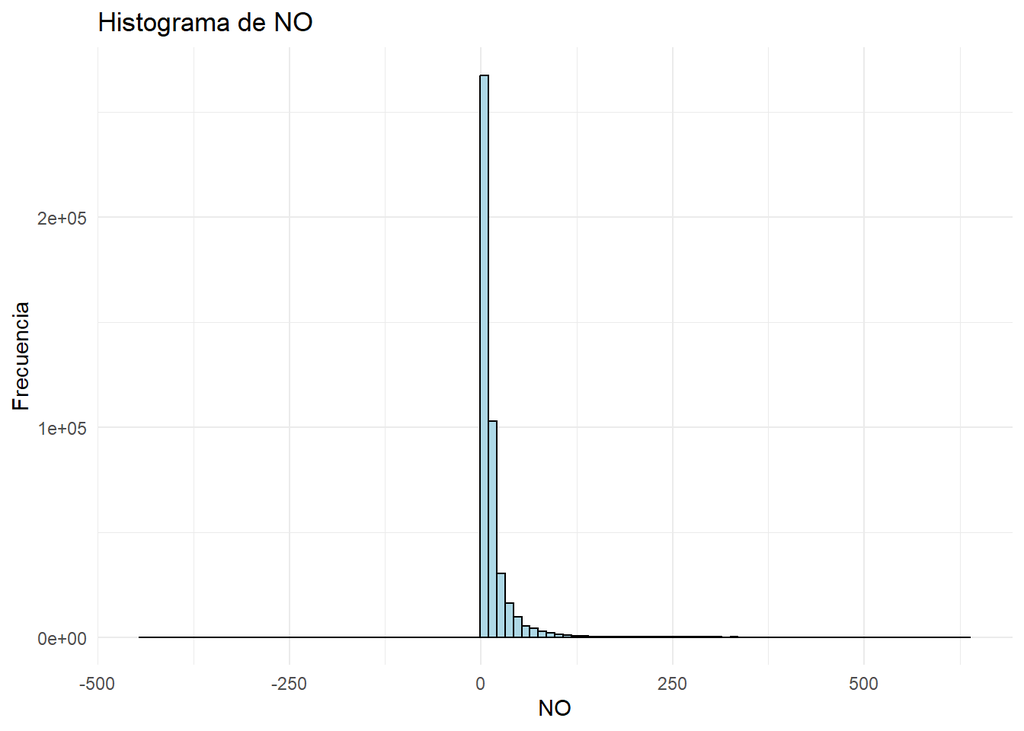

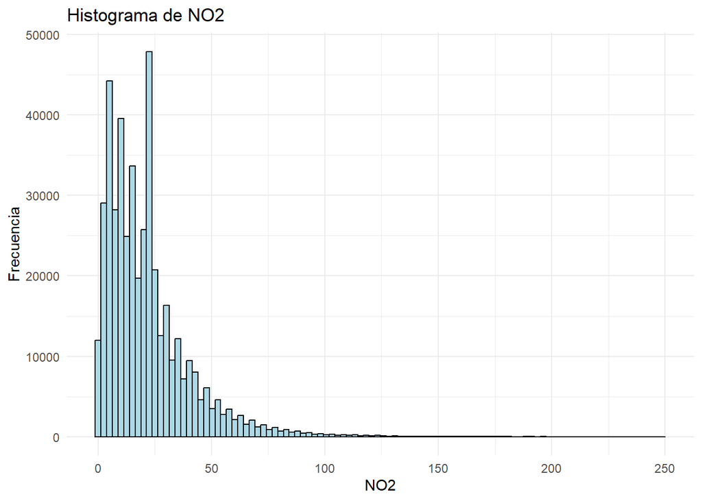

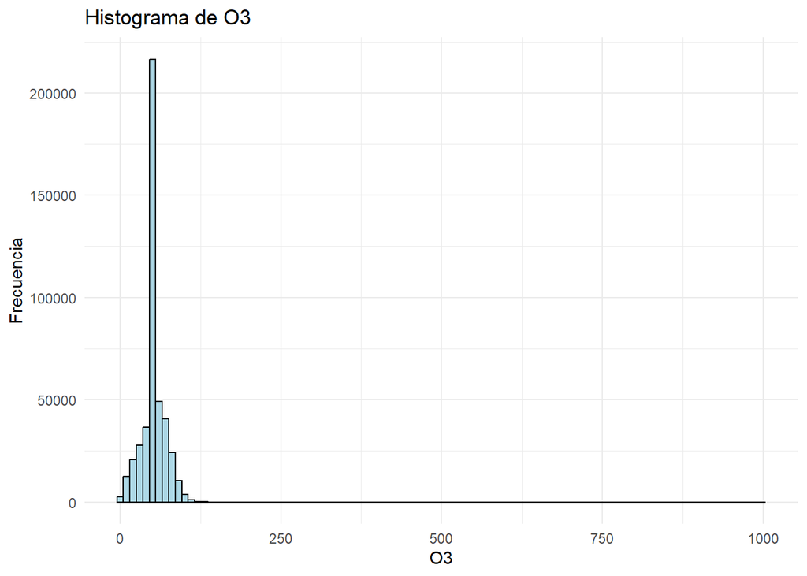

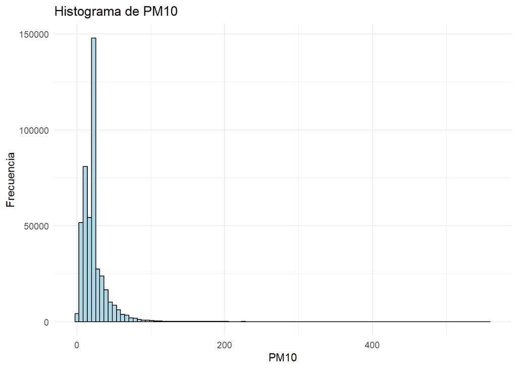

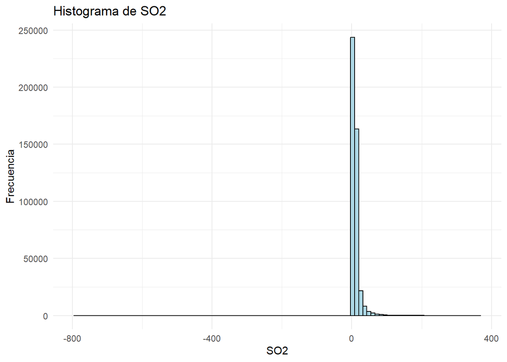

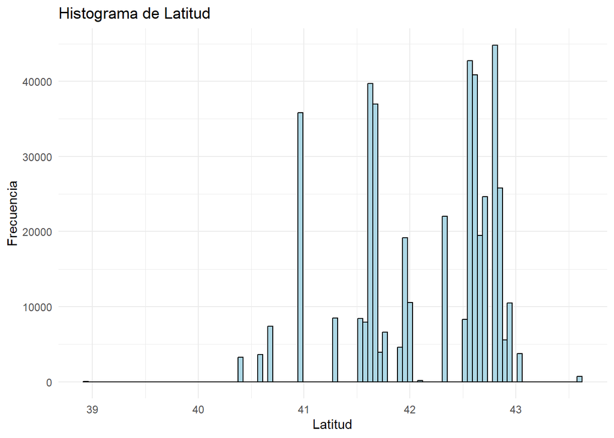

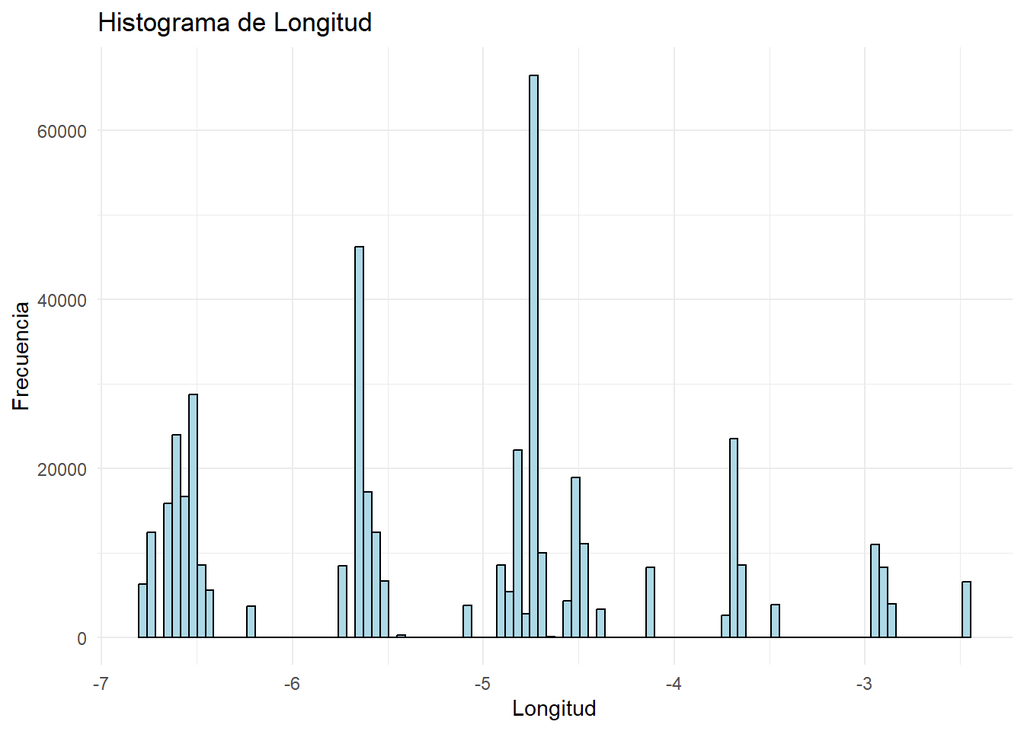

```r
# Obtener NOMBRES de columnas numéricas (no índices)
columnas_numericas <- names(calidad_aire)[sapply(calidad_aire, is.numeric)]

# Crear histogramas
for (col in columnas_numericas) {
  p <- ggplot(calidad_aire, aes(x = .data[[col]])) +
    geom_histogram(bins = 100, fill = "lightblue", color = "black") +
    labs(title = paste("Histograma de", col),
         x = col,
         y = "Frecuencia") +
    theme_minimal()
  print(p)
}
```